# Assignment 2: Spatial Analysis and Visualization

Healthcare Access and Equity in Pennsylvania

Author

Matthew Levy

Published

October 13, 2025

## Assignment Overview

**Learning Objectives:** - Apply spatial operations to answer policy-relevant research questions - Integrate census demographic data with spatial analysis - Create publication-quality visualizations and maps - Work with spatial data from multiple sources - Communicate findings effectively for policy audiences

## Part 1: Healthcare Access for Vulnerable Populations

### Research Question

**Which Pennsylvania counties have the highest proportion of vulnerable populations (elderly + low-income) living far from hospitals?**

Your analysis should identify counties that should be priorities for healthcare investment and policy intervention.

### Required Analysis Steps

Complete the following analysis, documenting each step with code and brief explanations:

#### Step 1: Data Collection (5 points)

Load the required spatial data: - Pennsylvania county boundaries - Pennsylvania hospitals (from lecture data) - Pennsylvania census tracts

**Your Task:**

```r
# Load required packages
library(knitr)
library(tidyverse)
library(tidycensus)
library(sf)
library(ggplot2)
library(tigris)
# Load spatial data

#census_api_key("YOUR KEY")

#Did not work
#options(tigris_use_cache = TRUE)
#options(tigris_progress = FALSE)  # Suppress tigris progress bars


# Check that all data loaded correctly

# Read a shapefile
countiesPA <- st_read("data/Pennsylvania_County_Boundaries.shp")
# Read GeoJSON
hospitals <- st_read("data/hospitals.geojson")
#tracts
ctPA <- tracts(state = "PA", cb = TRUE,
               progress = FALSE)
```

There are 233 hospitals and 3,445 census tracts. The hospital and counties are loaded in with WGS84 as their coordinate systems, whilst the census tracts have NAD83.

```r
# st_crs(ctPA)
# st_crs(countiesPA)
# st_crs(hospitals)
```

#### Step 2: Get Demographic Data

Use `tidycensus` to download tract-level demographic data for Pennsylvania.

**Your Task:**

```r
# Get demographic data from ACS
acs_vars_2023 <- load_variables(2023, "acs5",
                                cache = TRUE)

dataPA <- get_acs(
  geography = "tract",
  variables = c(popTotal = "B01003_001",
                medIncome = "B19013_001",
                male65 = "B01001A_014",
                male75 = "B01001A_015",
                male85 = "B01001A_016",
                woman65 = "B01001A_029",
                woman75 = "B01001A_030",
                woman85 = "B01001A_031"
                ),
  year = 2023, state = "PA", survey = "acs5",
  output = "wide")

dataPA <- dataPA %>%
  mutate(o65E = rowSums(across(c(
      male65E, male75E, male85E, woman65E,
      woman75E, woman85E))),
    o65M = rowSums(across(c(
      male65M, male75M, male85M, woman65M,
      woman75M, woman85M
  )))) %>% select(-c(male65E, male75E, male85E,
                  woman65E,woman75E, woman85E,
                  male65M, male75M, male85M,
                  woman65M, woman75M, woman85M))

# Join to tract boundaries
ctPA <- ctPA %>%
  left_join(dataPA, by = "GEOID")

#Number of NAs, median income
# length(ctPA$medIncomeE[is.na(ctPA$medIncomeE)])
# median(ctPA$medIncomeE, na.rm = TRUE)
```

I am using 5 year ACS data pertaining to total population, median income, and age. Out of the 3,445 census tracts, only 65 are missing their median income data. The median income of the remaining 3380 tracts is $72,943.50.

#### Step 3: Define Vulnerable Populations

Identify census tracts with vulnerable populations based on TWO criteria: 1. Low median household income (choose an appropriate threshold) 2. Significant elderly population (choose an appropriate threshold)

**Your Task:**

```r
# Filter for vulnerable tracts based on your criteria

incCrit <- (36777+29187)/2

ctPA <- ctPA %>%
  mutate(eldPercE = o65E/popTotalE,
         vuln = case_when(
           medIncomeE <= incCrit | eldPercE >= .2 ~ TRUE,
           TRUE ~ FALSE
         ))

ctVuln <- ctPA %>% filter(vuln)
```

#### Step 4: Calculate Distance to Hospitals

For each vulnerable tract, calculate the distance to the nearest hospital.

**Your Task:**

```r
# Transform to appropriate projected CRS

#South PA NAD83
ctPA <- st_transform(ctPA, 2272)
hospitals <- st_transform(hospitals, 2272)
countiesPA <- st_transform(countiesPA, 2272)
# st_crs(hospitals)


# Calculate distance from each tract centroid to nearest hospital

ctCent <- st_centroid(ctPA, 2272)

ctCent2 <- ctCent %>% mutate(
  hospDist = (apply(st_distance(.,hospitals),
                   1,
                   min))/5280)

# mean(ctCent2$hospDist)
# max(ctCent2$hospDist)
# nrow(ctCent2[ctCent2$hospDist > 15 & ctCent2$vuln,])
```

I chose the South Pennsylvania NAD83 projection because the study area is Pennsylvania and minimal distortions will occur from choosing one of the two state coordinate reference systems. The average distance is 4.41 miles. The maximum distance is 32.84 miles. There are 57 tracts that are both vulnerable (by my index of either 20% elderly or below an average income of $32,982) and more than 15 miles away from a hospital.

#### Step 5: Identify Underserved Areas

Define “underserved” as vulnerable tracts that are more than 15 miles from the nearest hospital.

**Your Task:**

```r
# Create underserved variable

ctCent2 <- ctCent2 %>% mutate(underserved = case_when(
  hospDist > 15 ~ TRUE,
  TRUE ~ FALSE
))



# nrow(ctCent2[ctCent2$underserved & ctCent2$vuln,])/nrow(ctCent2[ctCent2$vuln,])
# nrow(ctCent2[ctCent2$vuln,])
```

Out of the 1,369 vulnerable census tracts in Pennsylvania, only 57 of them are under-served in terms of distance from a hospital (over 15 miles away). This is not even 5% (~4.16%) of vulnerable tracts.

The number being *that* low surprises me; however, the number being low does not. I figured many of the older tracts may be located in some suburban and urban tracts and many of the poorer tracts located in urban tracts. A 15 mile radius is large enough to mean that any tract located near an urban center will most likely be near a hospital.

#### Step 6: Aggregate to County Level

Use spatial joins and aggregation to calculate county-level statistics about vulnerable populations and hospital access.

**Your Task:**

```r
# Spatial join tracts to counties

countyAgg <- ctCent2 %>% st_drop_geometry() %>%
  group_by(COUNTYFP) %>%
  summarise(
    totalPop = sum(popTotalE),
    weightedMedIncome = (sum(popTotalE*medIncomeE, na.rm = TRUE)/sum(popTotalE)),
    o65 = sum(o65E),
    o65Perc = o65/totalPop,
    avgDist = mean(hospDist),
    vulnTracts = sum(vuln),
    vulnPerc = 100*(sum(vuln)/n()),
    underservedTracts = sum(underserved),
    underservedPerc = 100* (sum(underserved & vuln)/sum(vuln)),
    vulnHospDist = mean(ifelse(vuln, hospDist, NA), na.rm = TRUE),
    vulnPop = sum(ifelse(vuln, popTotalE, 0)),
    vulnUndservPop = sum(ifelse(vuln & underserved, popTotalE, 0)),
    vulnUndservPerc = round(100*(vulnUndservPop/totalPop),2)
  )

# Aggregate statistics by county
countySummary <- countiesPA %>%
  mutate(COUNTYFP = FIPS_COUNT) %>%
  left_join(countyAgg, by = "COUNTYFP")
```

#### Step 7: Create Summary Table

Create a professional table showing the top 10 priority counties for healthcare investment.

**Your Task:**

```r
# Create and format priority counties table
priority <- countySummary %>%
  select(COUNTY_NAM, totalPop, vulnUndservPop, vulnUndservPerc ,vulnHospDist) %>%
  arrange(desc(vulnUndservPerc)) %>%
  st_drop_geometry()

priority$vulnUndservPerc <- paste(as.character(priority$vulnUndservPerc), "%", sep = "")
priority$vulnHospDist <- round(priority$vulnHospDist,2)


kable(priority[1:10, ],
      col.names = c("County", "County Population", "Vulnerable & Underserved Population",
                    "Vulnerable & Underserved Population Percent",
                    "Average Distance to Hospital for Vulnerable Population (miles)"
                    ),
      caption = "Top Ten Counties for Healthcare Investment PA",
      format.args = list(big.mark = ","))
```

Top Ten Counties for Healthcare Investment PA

| County | County Population | Vulnerable & Underserved Population | Vulnerable & Underserved Population Percent | Average Distance to Hospital for Vulnerable Population (miles) |
| --- | --- | --- | --- | --- |
| SULLIVAN | 5,849 | 5,849 | 100% | 22.67 |
| CAMERON | 4,475 | 4,475 | 100% | 19.07 |
| FOREST | 6,785 | 2,573 | 37.92% | 18.13 |
| PIKE | 59,691 | 17,101 | 28.65% | 17.86 |
| JUNIATA | 23,419 | 5,638 | 24.07% | 14.61 |
| CLEARFIELD | 78,902 | 18,790 | 23.81% | 13.55 |
| BRADFORD | 59,971 | 13,162 | 21.95% | 10.98 |
| TIOGA | 41,078 | 8,054 | 19.61% | 10.67 |
| WYOMING | 26,075 | 4,185 | 16.05% | 11.86 |
| HUNTINGDON | 43,844 | 6,413 | 14.63% | 11.58 |

## Part 2: Comprehensive Visualization

Using the skills from Week 3 (Data Visualization), create publication-quality maps and charts.

### Map 1: County-Level Choropleth

Create a choropleth map showing healthcare access challenges at the county level.

**Your Task:**

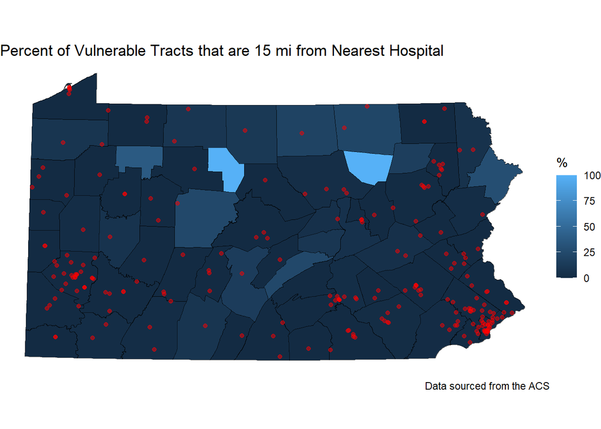

```r
# Create county-level access map
library(patchwork)


ggplot() +
  geom_sf(data= countySummary, aes(fill = vulnUndservPerc)) +
  geom_sf(data = hospitals, color = "red",
          alpha = .5,
          show.legend = TRUE) +
  theme_void() +
  labs(fill = "") +
  ggtitle("Percent of Vulnerable Tracts that are 15 mi from Nearest Hospital") +
  labs(caption = "Data sourced from the ACS", fill = "%")
```

### Map 2: Detailed Vulnerability Map

Create a map highlighting underserved vulnerable tracts.

**Your Task:**

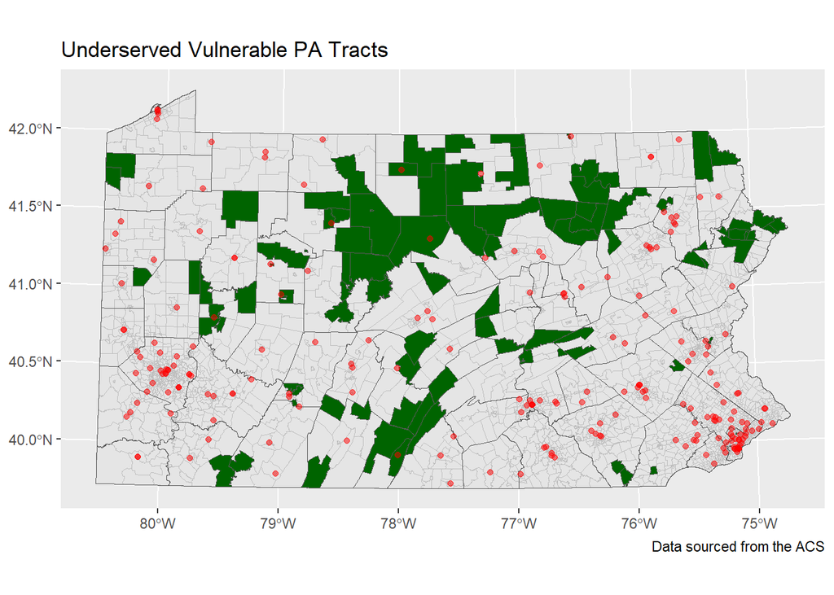

```r
# Create detailed tract-level map

#Get underserved info to tract shapefile
ctCent2 <- ctCent2 %>% select(TRACTCE, hospDist, underserved) %>% st_drop_geometry()
ctPA <- ctPA %>% left_join(ctCent2, by = "TRACTCE")

#Get shapefile of only underserved vulnerable tracts
ctVulnUndServ <- ctPA %>%
  filter(vuln & underserved)




ggplot() +
  geom_sf(data = ctPA, color = "grey",
          show.legend = FALSE) +
  geom_sf(data = ctVulnUndServ, fill = "darkgreen") +
  geom_sf(data = countiesPA, fill = "transparent") +
  geom_sf(data = hospitals, color = "red",
          alpha = .5) +
  ggtitle("Underserved Vulnerable PA Tracts") +
  labs(caption = "Data sourced from the ACS")
```

### Chart: Distribution Analysis

Create a visualization showing the distribution of distances to hospitals for vulnerable populations.

**Your Task:**

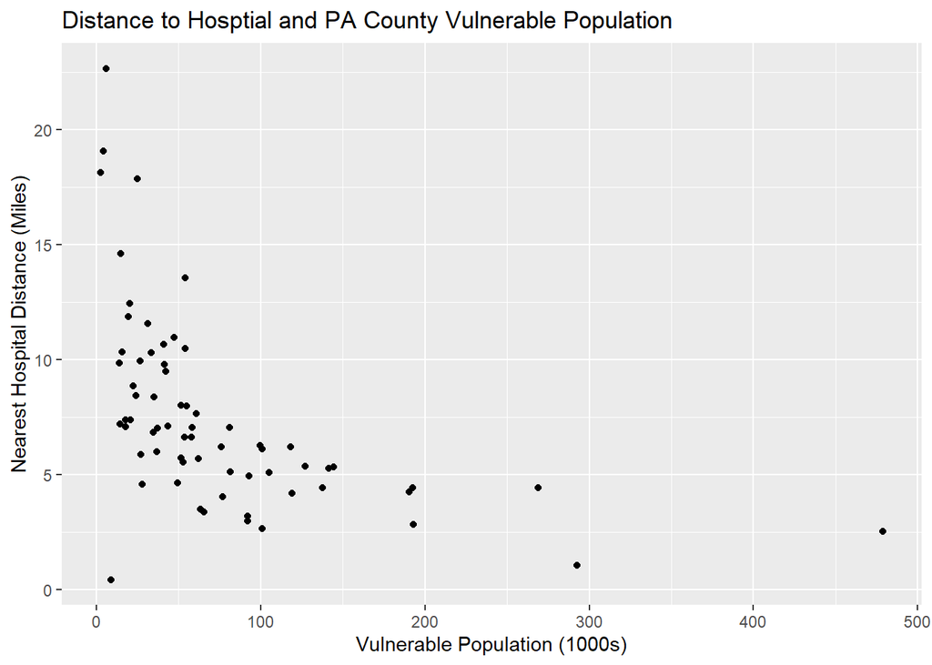

```r
# Create distribution visualization


ggplot(countySummary, aes(x = vulnPop/1000,
                          y = vulnHospDist)) +
  geom_point() +
  xlab("Vulnerable Population (1000s)") +
  ylab("Nearest Hospital Distance (Miles)") +
  ggtitle("Distance to Hosptial and PA County Vulnerable Population")
```

```r
print("The relationship between Pennsylvania county vulnerable populations and average distance from each county's census tracts to the nearest hospital. In this study, vulnerable populations are aggregated up from census tracts that are either 20% elderly (over the age of 65) or have an average income less than $32,982.")
```

[output not shown]

## Part 3: Bring Your Own Data Analysis

Choose your own additional spatial dataset and conduct a supplementary analysis.

### Your Analysis

**Your Task:**

1. **Find and load additional data**
   - Document your data source
   - Check and standardize the CRS
   - Provide basic summary statistics

```r
# Load your additional dataset
transitRoutes <- st_read("data/Transit_Routes_(Spring_2025).shp")
transit <- st_read("data/Transit_Stops_(Spring_2025).shp")
bike <- st_read("data/Bike_Network.shp")
bike <- st_transform(bike, 2272)
transit <- st_transform(transit, 2272)
transitRoutes <- st_transform(transitRoutes, 2272)



ctPA2 <- tracts(state = "PA", cb = TRUE)
ctPA2 <- st_transform(ctPA2, 2272)


dataPA2 <- get_acs(
  geography = "tract",
  variables = c(popTotal = "B01003_001",
                popAA = "B01001B_001",
                popLh = "B01001I_001",
                medIncome = "B19013_001",
                male65 = "B01001A_014",
                male75 = "B01001A_015",
                male85 = "B01001A_016",
                woman65 = "B01001A_029",
                woman75 = "B01001A_030",
                woman85 = "B01001A_031"
                ),
  year = 2023, state = "PA", survey = "acs5",
  output = "wide")

dataPA2 <- dataPA2 %>%
  mutate(o65E = rowSums(across(c(
      male65E, male75E, male85E, woman65E,
      woman75E, woman85E))),
    o65M = rowSums(across(c(
      male65M, male75M, male85M, woman65M,
      woman75M, woman85M
  )))) %>% select(-c(male65E, male75E, male85E,
                  woman65E,woman75E, woman85E,
                  male65M, male75M, male85M,
                  woman65M, woman75M, woman85M))

# Join to tract boundaries
ctPA2 <- ctPA2 %>%
  left_join(dataPA2, by = "GEOID")





#Standardizing measurements for demos
ctPA2 <- ctPA2 %>%
   mutate(percAA = 100 * (popAAE/popTotalE),
         percLH = 100*(popLhE/popTotalE),
         percOld = 100*(o65E/popTotalE))
# head(transit)
# head(transitRoutes)


#Prep to join
transitRouteGeoless <- transitRoutes %>% st_drop_geometry() %>%
  select(Mode, LineAbbr, LineName)


#Adding Consistency to Line Abbr
transitRouteGeoless$LineAbbr[transitRouteGeoless$LineAbbr == "T1 (10)"] <- "T1"
transitRouteGeoless$LineAbbr[transitRouteGeoless$LineAbbr == "G (15)"] <- "G1"
transitRouteGeoless$LineAbbr[transitRouteGeoless$LineAbbr == "63 (G)"] <- "63"
transitRouteGeoless$LineAbbr[transitRouteGeoless$LineAbbr == "51 (L)"] <- "51"
transitRouteGeoless$LineAbbr[transitRouteGeoless$LineAbbr == "41 (J)"] <- "41"
transitRouteGeoless$LineAbbr[transitRouteGeoless$LineAbbr == "81 (XH)"] <- "81"
transitRouteGeoless$LineAbbr[transitRouteGeoless$LineAbbr == "82 (R)"] <- "82"
transitRouteGeoless$LineAbbr[transitRouteGeoless$LineAbbr == "71 (H)"] <- "71"
transitRouteGeoless$LineAbbr[transitRouteGeoless$LineAbbr == "BSO"] <- "B1 OWL"
transitRouteGeoless$LineAbbr[transitRouteGeoless$LineAbbr == "MFO"] <- "L1 OWL"
transitRouteGeoless$LineAbbr[transitRouteGeoless$LineAbbr == "T2 (34)"] <- "T2"
transitRouteGeoless$LineAbbr[transitRouteGeoless$LineAbbr == "T3 (13)"] <- "T3"
transitRouteGeoless$LineAbbr[transitRouteGeoless$LineAbbr == "T4 (11)"] <- "T4"
transitRouteGeoless$LineAbbr[transitRouteGeoless$LineAbbr == "T5 (36)"] <- "T5"
transitRouteGeoless$LineAbbr[transitRouteGeoless$LineAbbr == "G (15)"] <- "G1"
transitRouteGeoless$LineAbbr[transitRouteGeoless$LineAbbr == "D1 BUS"] <- "D1 Bus"
transitRouteGeoless$LineAbbr[transitRouteGeoless$LineAbbr == "D2 BUS"] <- "D2 Bus"
transitRouteGeoless$LineAbbr[transitRouteGeoless$LineAbbr == "M"] <- "M1"


transit <- transit %>% left_join(transitRouteGeoless, by = "LineAbbr")

busStop <- transit %>% filter(Mode == "Bus")
metroStop <- transit %>% filter(grepl("Metro",Mode))


#Checking for mismatched lines
# stops <- transit %>% filter(is.na(Mode))
# unique(stops$LineAbbr)
```

I am using [SEPTA’s transit dataset](https://gis-septa.hub.arcgis.com/datasets/b227f3ddbe3e47b4bcc7b7c65ef2cef6_0/explore?location=40.076978%2C-75.278141%2C9.97), which was created by SEPTA and last updated on March 10, 2025. The transit data contains 22,478 features. I chose to work with this data because of my interest in transit equity/justice. They were originally in WGS84, so I transformed it to South Pennsylvania’s NAD83 to be consistent with my previous work in this assignment.

2. **Pose a research question**

Do vulnerable and minority tracts have equitable access to the metro and safe (protected) bike lanes?

3. **Conduct spatial analysis**

Use at least TWO spatial operations to answer your research question.

**Your Task:**

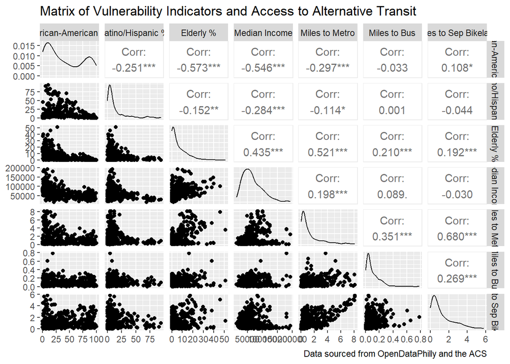

```r
#get philadelphia county
phl <- countiesPA %>% filter(FIPS_COUNT == "101")


#Limit all shapefiles to both desired type and desired location (philadelphia)
ctPHL <- ctPA2 %>% filter(COUNTYFP == "101")

metroStopPHL <- metroStop %>% st_filter(phl, .predicate = st_intersects)
busStopPHL <- busStop %>% st_filter(phl, .predicate = st_intersects)


# unique(bike$TYPE)

sepBike <- bike %>% filter(grepl("Separated",TYPE))

#Get centroids to calc distance between census tracts and transit ooptions
phlCTCent <- st_centroid(ctPHL, 2272)
phlCTCent <- st_transform(phlCTCent, 2272)
phlCTCent <- phlCTCent %>% mutate(
  metroDist = (apply(st_distance(.,metroStopPHL),
                   1,
                   min))/5280,
  busDist = (apply(st_distance(.,busStopPHL),
                   1,
                   min))/5280,
  bikeDist = (apply(st_distance(.,sepBike),
                   1,
                   min))/5280
  )





library("GGally")

#Put desried variables into its own tibble for scatterplot matrix
vars <- phlCTCent %>% select("African-American %" = percAA,
                             "Latino/Hispanic %" = percLH,
                             "Elderly %" = percOld,
                             "Median Income" = medIncomeE,
                             "Miles to Metro" = metroDist,
                             "Miles to Bus" = busDist,
                             "Miles to Sep Bikelane" = bikeDist) %>%
  st_drop_geometry()

#Scatterplot Matrix
ggpairs(vars, na.rm = TRUE) +
  ggtitle("Matrix of Vulnerability Indicators and Access to Alternative Transit") +
  labs(caption = "Data sourced from OpenDataPhilly and the ACS")
```

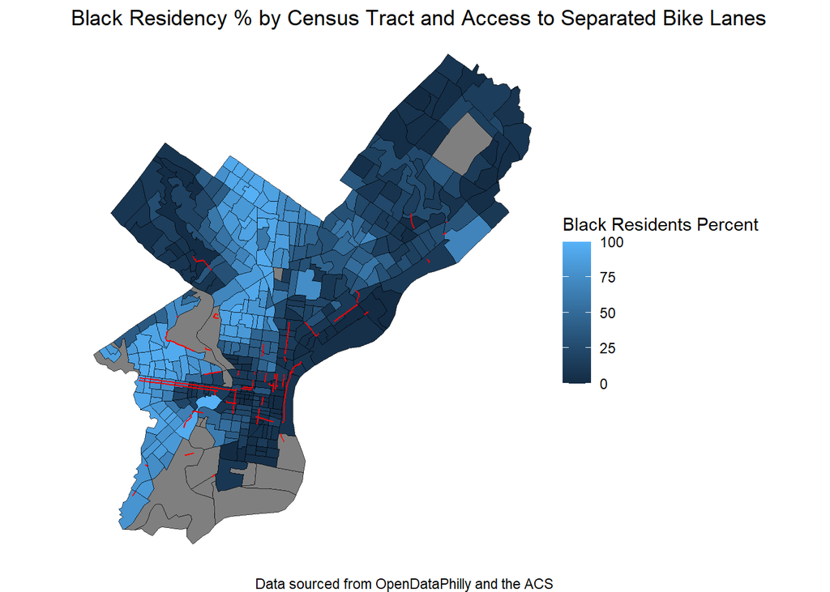

```r
#Adding distance vars to census tract shapefiles for map
  #Did not use a spatial join bc an oddly shaped tract can theoretically have a centroid outside of its
  #boundaries (e.g. if it is shaped like a 'C')
dist <- phlCTCent %>% select(metroDist, busDist, bikeDist, TRACTCE) %>%
  st_drop_geometry()
ctPHL <- ctPHL %>% left_join(dist, by = "TRACTCE")


#Map
ggplot() +
  geom_sf(data = ctPHL, aes(fill = percAA)) +
  geom_sf(data = sepBike, color = "red") + theme_void() +
  labs(fill = "Black Residents Percent",
       caption = "Data sourced from OpenDataPhilly and the ACS") +
  ggtitle("Black Residency % by Census Tract and Access to Separated Bike Lanes")
```

```r
#summary stats
summary(vars)
```

```
 African-American % Latino/Hispanic %   Elderly %      Median Income
 Min.   :  0.000    Min.   : 0.000    Min.   : 0.000   Min.   : 13721
 1st Qu.:  9.164    1st Qu.: 3.579    1st Qu.: 0.726   1st Qu.: 42469
 Median : 29.468    Median : 6.867    Median : 3.689   Median : 60817
 Mean   : 39.835    Mean   :13.608    Mean   : 6.849   Mean   : 66877
 3rd Qu.: 75.069    3rd Qu.:15.062    3rd Qu.:10.182   3rd Qu.: 85298
 Max.   :100.000    Max.   :94.412    Max.   :51.263   Max.   :192727
 NA's   :17         NA's   :17        NA's   :17       NA's   :27
 Miles to Metro      Miles to Bus      Miles to Sep Bikelane
 Min.   :0.005674   Min.   :0.001602   Min.   :0.0005466
 1st Qu.:0.254574   1st Qu.:0.035219   1st Qu.:0.3335425
 Median :0.630312   Median :0.063175   Median :0.7684063
 Mean   :1.405345   Mean   :0.104072   Mean   :1.2078553
 3rd Qu.:1.774397   3rd Qu.:0.150305   3rd Qu.:1.7762018
 Max.   :8.096933   Max.   :0.786101   Max.   :5.8042876
```

**Interpretation:** Whilst my scatterplot matrix did not show any extraordinarily strong correlation between my variables and distance metrics, I found that visualizing the different transportation types with different variables provided interesting results. The strongest instance of this is my map of separated bike lanes overlaying a chloropleth of percentage of Black residency in tracts, which is notably negatively correlated. Another interesting note is that the shape of most variable-distance relationships were negatively sloped or curved; however, median income’s relationship tended to look more like normal distribution (not that it was normally distributed).

## Finally - A few comments about your incorporation of feedback!

Take a few moments to clean up your markdown document and then write a line or two or three about how you may have incorporated feedback that you recieved after your first assignment.

My biggest incorporation of feedback was in cleaning and commenting out my Quarto doc. I now ensured that my offline rendering worked before trying to upload to git.

## Submission Requirements

**What to submit:**

1. **Rendered HTML document posted to your course portfolio** with all code, outputs, maps, and text
   - Use `embed-resources: true` in YAML so it’s a single file
   - All code should run without errors
   - All maps and charts should display correctly

**File naming:** `LastName_FirstName_Assignment2.html` and `LastName_FirstName_Assignment2.qmd`